# Relationship between Mental Health and Social Media Usage

## Relationship between Mental Health and Social Media Usage

### Authors

Olivia Kim

Christina Wang

Chae Won Yoo

Harshita Singh

### Date

4/30/2024

## Abstract

Our main question for this project is how social media usage affects the mental health of an individual, especially young adults. This question is important because if these two variables show a causal relationship, potential solutions should be explored to mitigate this detrimental effect of social media in creating and worsening mental issues. To address this concern, we plan to analyze the dataset we have found using R to study the relationship between social media usage and mental fitness.

## Keywords

Keywords: mental health, social media, screen time, young adults

## Proposal

### 1. Introduction

In the modern world, social media is part of many individuals’ daily lives, especially for young adults. The wide usage of applications such as Instagram, TikTok, and Twitter has created concerns about over-usage and potential negative consequences such as mental health issues. Many contents on these platforms are inappropriate and negative as they include hate-based information or comments as well as negative self or body image. Therefore, exploring the relationship between social media usage and mental fitness is necessary, especially as the Social Media Industry continues to grow rapidly. Through this project, we hope to contribute to this goal by analyzing a dataset we have found, discussed in more detail in section three of our proposal, to answer the research questions we have focused on. Some questions we aim to answer are what are the age ranges that are most affected by social media, what are the proportions of individuals experiencing positive or negative changes in mental health from social media, how many participants have an underlying mental condition in this study, and does social media screentime affect the likeliness of mental health issue. These research questions are important to answer as they potentially show the relationship between mental health and social media and help to draw associations between these two variables.

### 2. Related Work

> Nakshine VS, Thute P, Khatib MN, Sarkar B. Increased Screen Time as a Cause of Declining Physical, Psychological Health, and Sleep Patterns: A Literary Review. Cureus. 2022 Oct 8;14(10):e30051. doi: 10.7759/cureus.30051. PMID: 36381869; PMCID: PMC9638701.

> Kerai, S., Almas, A., Guhn, M. et al. Screen time and developmental health: results from an early childhood study in Canada. BMC Public Health 22, 310 (2022). https://doi.org/10.1186/s12889-022-12701-3

### 3. The Dataset

Link: https://dataverse.harvard.edu/dataset.xhtml?persistentId=doi:10.7910/DVN/JBPZ9E

### 4. Implications

> Assuming you answer your research questions, briefly describe the expected or possible implications for technologists, designers, and policymakers. (at least 150 words)

If our study confirms that using social media causes mental health problems, it would be a big deal for many people. People who make social media apps might start thinking about making them better for our mental health instead of just trying to keep us hooked. They could add mandatory timers to limit how much time we spend on them, warnings about harmful content across all platforms, or tools to deal with mean comments. Government officials must make rules to protect us from spending too much time on social media, especially young people. Therapists could use what we find to help people who are struggling with how social media affects their mental health. This could lead to a positive movement and impact how social media is socially viewed. Social media would be a fundamental tension for policymakers and legislation from now on as there would be differing opinions on matters as that is the nature of government.

### 5. Limitations & Challenges

> What challenges or limitations might you need to address with your project idea more broadly? Briefly discuss. (at least 150 words)

One challenge is showing that using social media leads to mental health issues, showing causality. While our analysis can show connections, proving that one causes the other is tricky. We’ll need to think carefully about other things that might be causing both, and whether using social media might be caused by mental health problems. Also, since we only looked at data from a small sample in Colorado and not from a broader pool, our findings might not apply to everyone. Attempting to gather reliable data from a large sample size where we take out response bias would be very difficult. Also, factoring in our confounding variables with research of this magnitude would further add to the list of limitations. We must protect people’s privacy and not let our opinions influence our research. Working out how social media affects mental health needs lots of different experts to help, which could lead to various challenges.

### Summary Information

The 5 values I calculated are the number of row, number of columns, average daily hours spent on social media, percentage of participants that use social media everyday, and the highest number of hours spent on social media per week among participants. The dataset has 55 rows and 41 columns. That means that there are 55 participants in total and 41 questions asked in the survey. The reported average hours spent daily on social media is 3.06 hours. The percentage of people that report using social media daily is 89.1 percent. The highest number of hours spent on social media per week among participants is 112 hours.

### Table

[output not shown]

| mental_health_history | daily_hours_spent | weekly_hours_spent | feel_peer_pressure |
| --- | --- | --- | --- |
| 0 | 3.0 | 21.0 | 0 |
| 1 | 2.0 | 14.0 | 0 |
| 0 | 3.0 | 20.0 | 1 |
| 1 | 4.0 | NA | 0 |
| 1 | 4.0 | 30.0 | 0 |
| 0 | 2.0 | 10.0 | 0 |
| 1 | NA | 2.0 | 0 |
| 1 | NA | NA | 0 |
| 1 | 2.5 | 13.0 | 0 |
| 1 | 1.0 | 10.0 | 0 |
| 0 | 2.0 | 8.0 | 0 |
| 1 | 3.0 | 21.0 | 0 |
| 1 | 1.0 | 7.0 | 0 |
| 0 | 5.0 | 30.0 | 0 |
| 1 | 1.0 | 1.0 | 0 |
| 0 | 2.0 | 10.0 | 0 |
| 0 | 3.0 | 20.0 | 0 |
| 1 | 2.0 | 18.0 | 0 |
| 1 | 0.5 | 3.5 | 0 |
| 1 | 3.0 | 21.0 | 1 |
| 0 | 1.0 | 7.0 | 0 |
| 1 | 5.0 | 35.0 | 2 |
| 1 | 7.0 | 35.0 | 0 |
| 1 | 0.5 | 3.5 | 0 |
| 0 | NA | NA | 0 |
| 0 | 2.0 | 14.0 | 2 |
| 1 | 2.0 | 14.0 | 1 |
| 1 | 2.0 | 12.0 | 0 |
| 1 | 2.0 | 10.0 | 1 |
| 1 | 5.0 | 25.0 | 0 |
| 0 | 3.0 | 17.0 | 0 |
| 0 | 4.0 | 30.0 | 0 |
| 0 | 5.0 | 30.0 | 0 |
| 0 | 8.0 | 56.0 | 0 |
| 1 | 0.0 | 0.0 | 0 |
| 1 | 3.0 | 30.0 | 0 |
| 0 | 2.0 | 20.0 | 0 |
| 1 | 2.0 | 10.0 | 0 |
| 1 | 6.0 | 42.0 | 0 |
| 0 | 4.0 | 16.0 | 0 |
| 1 | 16.0 | 112.0 | 0 |
| 0 | 2.0 | 15.0 | 0 |
| 0 | 0.5 | 4.0 | 0 |
| 1 | 3.0 | 9.0 | 0 |
| 1 | 5.0 | 35.0 | 0 |
| 0 | 2.0 | 8.0 | 0 |
| 0 | 5.0 | 30.0 | 1 |
| 0 | 1.0 | 7.0 | 0 |
| 1 | 1.0 | 7.0 | 0 |
| 1 | 1.0 | 9.0 | 0 |
| 0 | 2.0 | 8.0 | 0 |
| 0 | 3.0 | 21.0 | 0 |
| 1 | 5.0 | 7.0 | 0 |
| 1 | 3.0 | 21.0 | 0 |
| 1 | 2.0 | 14.0 | 0 |

Describe why you included the table and what information it reveals

The table reveals information about the particapants daily as well as weekly social media use - which helps us understand and compare how mental health is affected by the increase or decrease in social media use. We also have columns where particapants share whether they feel pressured to obtain likes and followers on social media which further helps us understand its negative effects.

### Chart 1

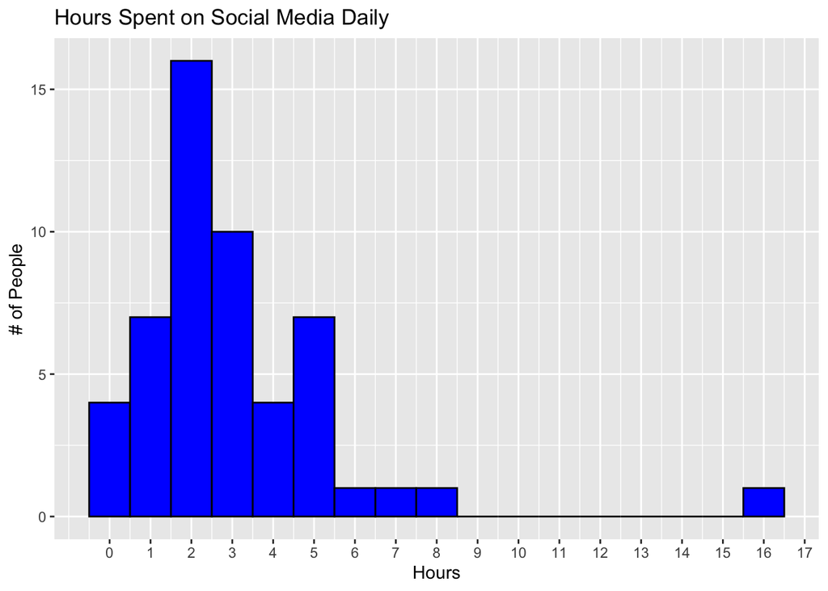

Describe why you chose this chart and what information it reveals

I chose to graph this histogram because we wanted to see the overall distribution of social media usage daily. This chart reveals that most participants of this survey spent time on social media ranging from 1 - 5hrs daily.

### Chart 2

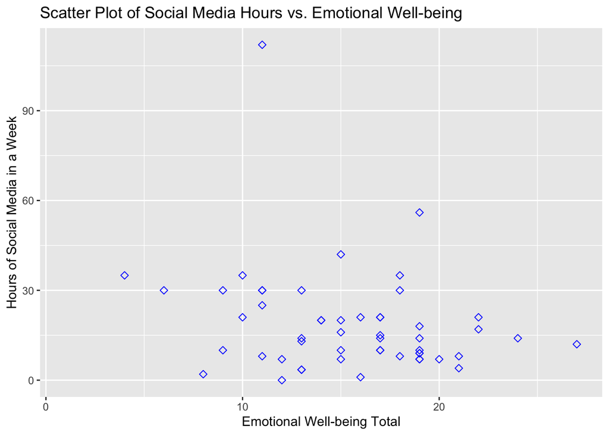

Describe why you chose this chart and what information it reveals

I chose this graph because I believe it helps show the tendencies and correlation between social media use and emotional well-being. The chart very clearly shows where the larger clusters of people are dependent on the usage of social media, and a easy visualization such as a scatter plot allows for better discrepancy.

### Chart 3

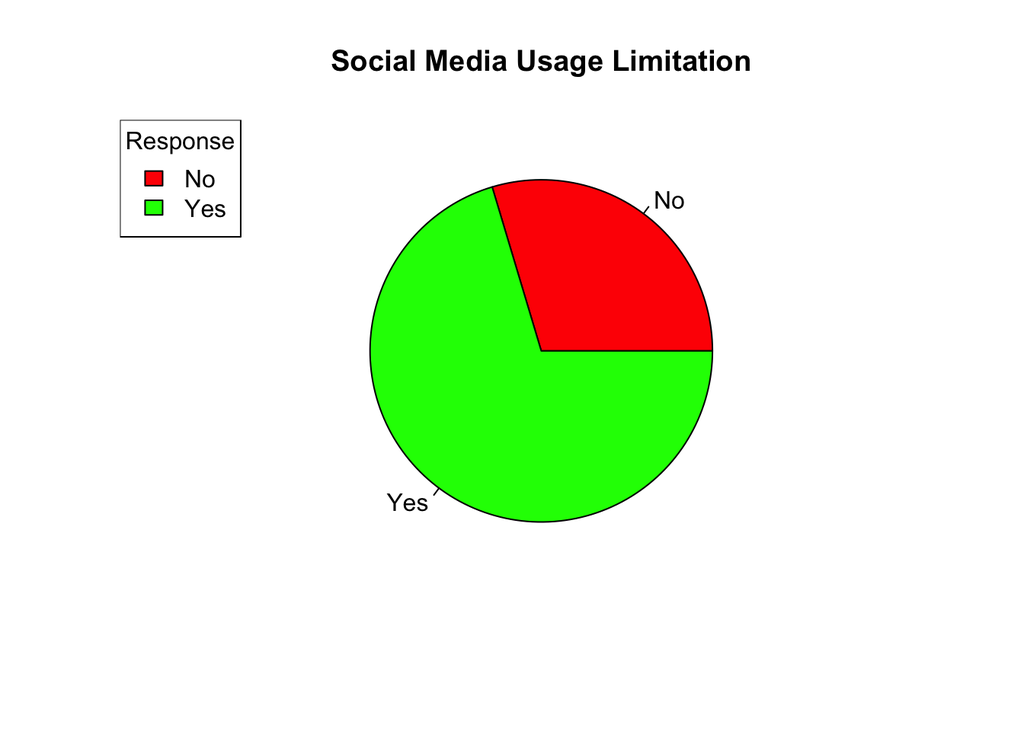

Describe why you chose this chart and what information it reveals I chose this chart because it helps us to clearly visualise how many people reponded yes to wanting to limit their social media usage as compared to those who don’t. It shows that more often than not people wish to reduce their usage showing that they realise its damaging effects.